# Week 3 Clustering

Coleman Strickland

18 October 2021

# Clustering Example

## Process data

```r
library(cluster)
library (fpc)
library(MASS)
library (treeClust)
rm(list=ls())
setwd("/home/cwstrick/Coleman/Week3/")
set.seed(2012)
```

## Load and Construct Matrix

We use the biopsy data set for this assignment, dropping the ID column, setting any missing values to 0, and separating our features from the response variable “class”. Our final matrix consists of 699 rows with 9 columns.

```r
biopsy_clust<-biopsy
biopsy_clust$ID<-NULL
biopsy_clust[is.na(biopsy_clust)] = 0
biopsy_y<-biopsy_clust$class
biopsy_x<-biopsy_clust[,1:9]
dim(biopsy_x)
```

```
## [1] 699   9
```

## Clustering Technique 1: Kmeans

Our first clustering technique is to use kmeans. We start by setting the number of clusters to 5, and ensure we give an nstart of 1000 for a max of 100 iterations. To ensure we are at a global optimal value, we execute two clustering runs and compare the results. Analyzing the table of results, we see both of our runs have concluded with the same number of results per cluster; therefore, our parameter values appear to be achieving the intended results.

```r
biopsy_clust.km1 <- kmeans (scale (biopsy_x), 5, nstart=1000, iter.max=100)
biopsy_clust.km2 <- kmeans (scale (biopsy_x), 5, nstart=1000, iter.max=100)
table (biopsy_clust.km1$cluster, biopsy_clust.km2$cluster) #both runs agree
```

```
##
##       1   2   3   4   5
##   1  30   0   0   0   0
##   2   0   0   0  48   0
##   3   0   0 451   0   0
##   4   0   0   0   0  84
##   5   0  86   0   0   0
```

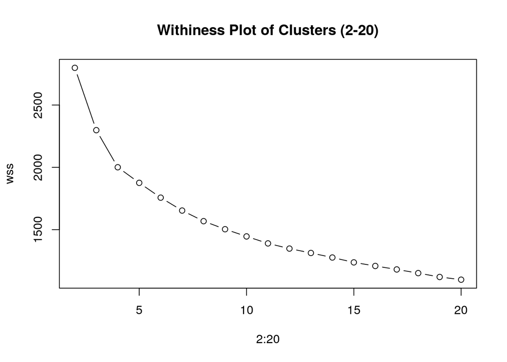

```r
wss <- numeric (length (2:20))
names (wss) <- 2:20
for (i in 2:20)  {
    out <- kmeans (scale (biopsy_x), i, nstart=1000, iter.max=100)
    wss[as.character (i)] <- out$tot.withinss
}
plot (2:20, wss, type = "b")
title('Withiness Plot of Clusters (2-20)')
```